# Crime Busters Drugs

2022-10-08

```r
library(tidyverse)
library(tsibble)
library(feasts)
library(fpp3)
```

```r
library(dplyr)
library(ggplot2)
library(lubridate)
library(janitor)
library(bbplot)
data = read_csv("Clearances_data.csv")
data$Date = as.Date(data$`Month Year`, "%d/%m/%Y")
```

```r
data$Month = yearmonth(data$Date)
prosecution.df = filter(data, `Police Action` == "Prosecution")
prosecution.df
```

```
## # A tibble: 102 × 6
##    `Pre or Post MODA` `Month Year` `Police Action` Clearan…¹ Date          Month
##    <chr>              <chr>        <chr>               <dbl> <date>        <mth>
##  1 Pre-MODA           01/03/2013   Prosecution           581 2013-03-01 2013 Mar
##  2 Pre-MODA           01/04/2013   Prosecution           588 2013-04-01 2013 Apr
##  3 Pre-MODA           01/05/2013   Prosecution           637 2013-05-01 2013 May
##  4 Pre-MODA           01/06/2013   Prosecution           502 2013-06-01 2013 Jun
##  5 Pre-MODA           01/07/2013   Prosecution           479 2013-07-01 2013 Jul
##  6 Pre-MODA           01/08/2013   Prosecution           502 2013-08-01 2013 Aug
##  7 Pre-MODA           01/09/2013   Prosecution           401 2013-09-01 2013 Sep
##  8 Pre-MODA           01/10/2013   Prosecution           391 2013-10-01 2013 Oct
##  9 Pre-MODA           01/11/2013   Prosecution           396 2013-11-01 2013 Nov
## 10 Pre-MODA           01/12/2013   Prosecution           411 2013-12-01 2013 Dec
## # … with 92 more rows, and abbreviated variable name ¹Clearances
## # ℹ Use `print(n = ...)` to see more rows
```

```r
library(data.table)
data_v2 <- setDT(prosecution.df)[ , .(Clearances_month = sum(Clearances)), by = Month]
data_v2
```

```
##         Month Clearances_month
##   1: 2013 Mar              581
##   2: 2013 Apr              588
##   3: 2013 May              637
##   4: 2013 Jun              502
##   5: 2013 Jul              479
##  ---
##  98: 2021 Apr              403
##  99: 2021 May              449
## 100: 2021 Jun              383
## 101: 2021 Jul              367
## 102: 2021 Aug              384
```

```r
data_v3 <- data_v2 %>%
  as_tsibble(index=Month) %>%
  arrange(., Month)
data_v3
```

```
## # A tsibble: 102 x 2 [1M]
##       Month Clearances_month
##       <mth>            <dbl>
##  1 2013 Mar              581
##  2 2013 Apr              588
##  3 2013 May              637
##  4 2013 Jun              502
##  5 2013 Jul              479
##  6 2013 Aug              502
##  7 2013 Sep              401
##  8 2013 Oct              391
##  9 2013 Nov              396
## 10 2013 Dec              411
## # … with 92 more rows
## # ℹ Use `print(n = ...)` to see more rows
```

Plot whole data, plus seasonal data:

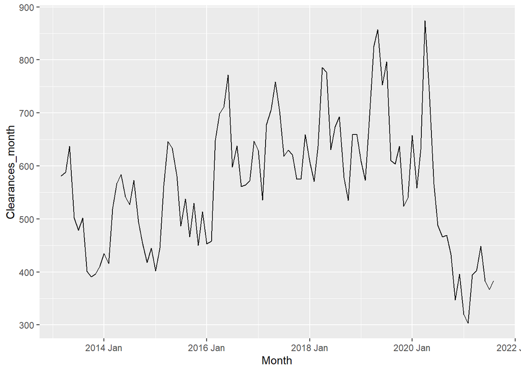

```r
data_v3 %>%
ggplot(aes(Month, Clearances_month))+geom_line()
```

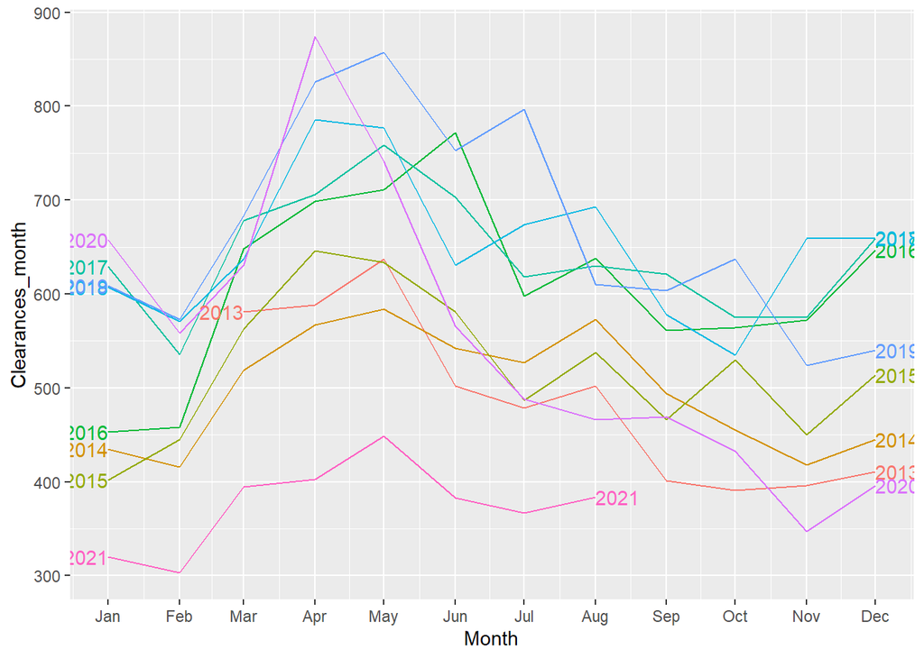

```r
data_v3 %>%
gg_season(Clearances_month, labels = "both")
```

General plot shows increasing trend, with a massive drop in May 2020. Variance fairly constant?

Seasonal plot shows that possibly number of prosecutions is highest at the middle of the year

We now filter our dataset, to only include data pre-MODA changes:

```r
pre_moda <- data_v3 %>%
  filter(Month >= yearmonth("2013 Mar"), Month <= yearmonth("2019 Jul"))
pre_moda
```

```
## # A tsibble: 77 x 2 [1M]
##       Month Clearances_month
##       <mth>            <dbl>
##  1 2013 Mar              581
##  2 2013 Apr              588
##  3 2013 May              637
##  4 2013 Jun              502
##  5 2013 Jul              479
##  6 2013 Aug              502
##  7 2013 Sep              401
##  8 2013 Oct              391
##  9 2013 Nov              396
## 10 2013 Dec              411
## # … with 67 more rows
## # ℹ Use `print(n = ...)` to see more rows
```

Within per_moda, we need to create a training set and a test set to test model accuracy. Let’s use the last year (roughly 20% of the data) as test data

```r
training <- pre_moda %>%
  filter(Month >= yearmonth("2013 Mar"), Month <= yearmonth("2018 Jul"))
training
```

```
## # A tsibble: 65 x 2 [1M]
##       Month Clearances_month
##       <mth>            <dbl>
##  1 2013 Mar              581
##  2 2013 Apr              588
##  3 2013 May              637
##  4 2013 Jun              502
##  5 2013 Jul              479
##  6 2013 Aug              502
##  7 2013 Sep              401
##  8 2013 Oct              391
##  9 2013 Nov              396
## 10 2013 Dec              411
## # … with 55 more rows
## # ℹ Use `print(n = ...)` to see more rows
```

We can now analyse this training set and fit models!

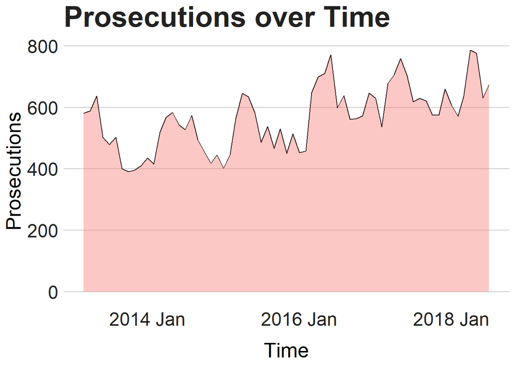

```r
training %>%
ggplot(aes(Month, Clearances_month))+geom_line()+geom_area(fill = scales::hue_pal()(1), alpha = 0.4) +
  bbc_style() +
  labs(title = 'Prosecutions over Time',
       x = 'Time', y = 'Prosecutions') +
  theme(axis.title = element_text(size = 20))
```

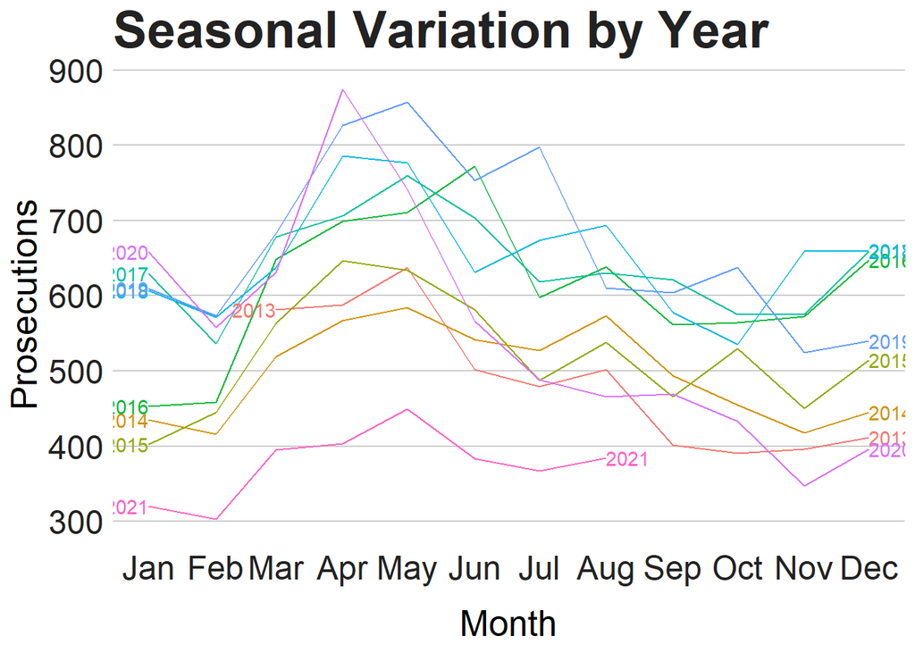

```r
ggsave('test2.png')
data_v3 %>%
gg_season(Clearances_month, labels = "both") +
  bbc_style() +
  labs(title = 'Seasonal Variation by Year',
       x = 'Month', y = 'Prosecutions') +
  theme(axis.title = element_text(size = 20))
```

```r
ggsave('test.png')
```

Variability is nonconstant as level increases, so transform.

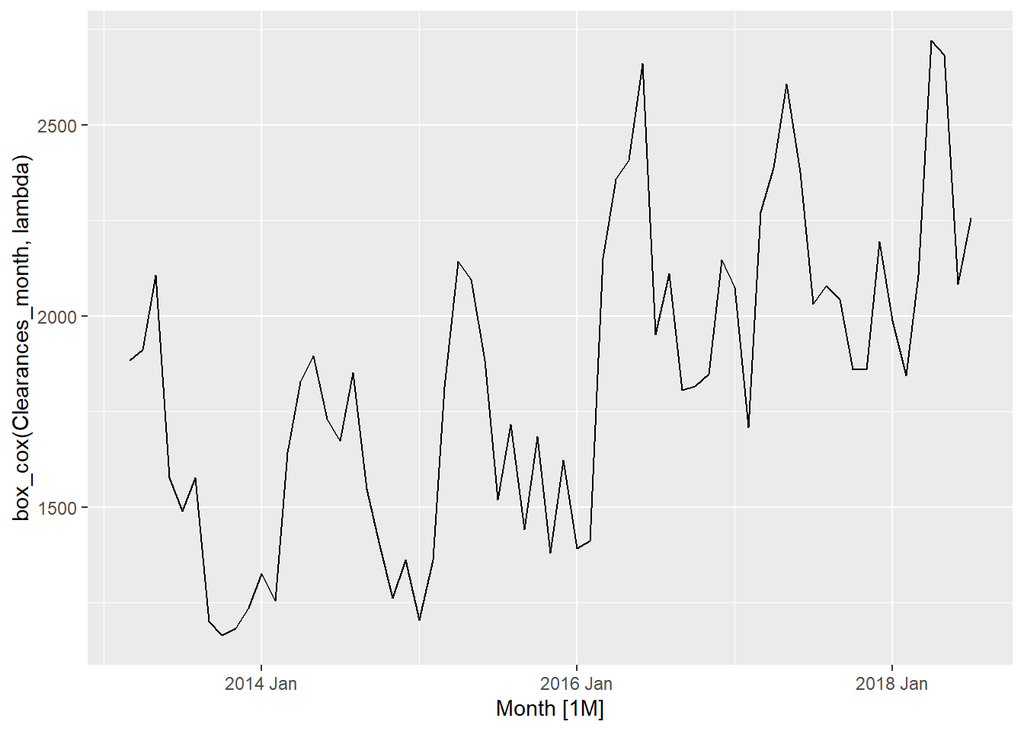

```r
lambda <- training %>%
features(Clearances_month, features = guerrero) %>%
pull(lambda_guerrero)
training %>% autoplot(box_cox(Clearances_month, lambda))
```

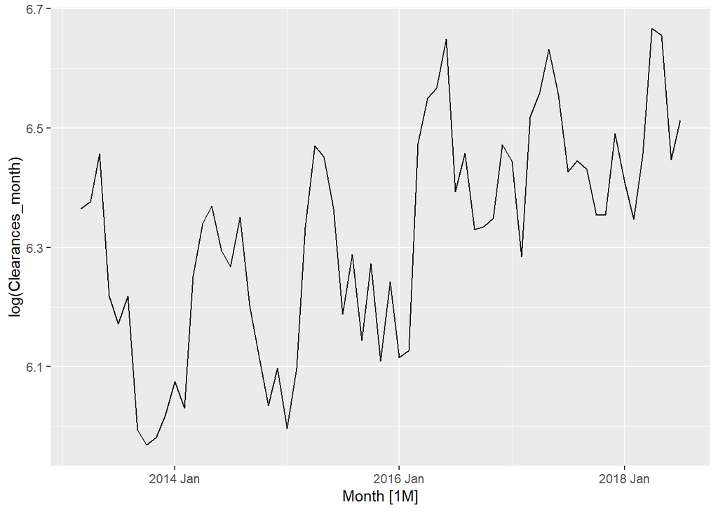

```r
training %>% autoplot(log(Clearances_month))
```

Let’s first fit some ETS (Error, Trend, Seasonality) models:

```r
ETSmodels <- training %>%
  model(
    Additive = ETS(box_cox(Clearances_month, lambda) ~
                        error("A") + trend("A") + season("A")),
    Additive_Dampened = ETS(box_cox(Clearances_month, lambda) ~
                           error("A") + trend("Ad") + season("A")),
    Multiplicative = ETS(box_cox(Clearances_month, lambda) ~ error("M") +
                                        trend("A") + season("M")),
    Multiplicative_Damped = ETS(box_cox(Clearances_month, lambda) ~
                        error("M") + trend("Ad") + season("M")),
    ets = ETS(box_cox(Clearances_month, lambda))
        )
ETSmodels %>% pivot_longer(everything(), names_to = "Model_name",
values_to = "Orders")
```

```
## # A mable: 5 x 2
## # Key:     Model_name [5]
##   Model_name                   Orders
##   <chr>                       <model>
## 1 Additive               <ETS(A,A,A)>
## 2 Additive_Dampened     <ETS(A,Ad,A)>
## 3 Multiplicative         <ETS(M,A,M)>
## 4 Multiplicative_Damped <ETS(M,Ad,M)>
## 5 ets                    <ETS(M,N,A)>
```

```r
report(ETSmodels)
```

```
## # A tibble: 5 × 9
##   .model                  sigma2 log_lik   AIC  AICc   BIC    MSE   AMSE     MAE
##   <chr>                    <dbl>   <dbl> <dbl> <dbl> <dbl>  <dbl>  <dbl>   <dbl>
## 1 Additive               2.97e+4   -461.  956.  969.  993. 22376. 23859. 1.14e+2
## 2 Additive_Dampened      3.11e+4   -462.  960.  975.  999. 22939. 24704. 1.16e+2
## 3 Multiplicative         8.79e-3   -460.  953.  967.  990. 24660. 30357. 6.45e-2
## 4 Multiplicative_Damped  9.13e-3   -460.  956.  971.  995. 23660. 28917. 6.32e-2
## 5 ets                    8.72e-3   -460.  950.  960.  982. 23300. 26620. 6.48e-2
```

We now look at forecast accuracy on our test set (the last year before MODA changes)

```r
forecastETS <- ETSmodels %>%
  forecast(h=12)
accuracy(forecastETS, pre_moda) %>%
  select(.model, RMSE, MAE, MAPE, MASE)
```

```
## # A tibble: 5 × 5
##   .model                 RMSE   MAE  MAPE  MASE
##   <chr>                 <dbl> <dbl> <dbl> <dbl>
## 1 Additive               56.3  42.9  6.11 0.765
## 2 Additive_Dampened      64.6  48.9  6.85 0.873
## 3 ets                    72.1  55.8  7.73 0.994
## 4 Multiplicative         57.6  45.6  6.61 0.814
## 5 Multiplicative_Damped  63.7  49.9  7.04 0.889
```

We now look at ARIMA models. We first need to check if we need seasonal differencing and differencing (as ARIMA models assume that data is stationary, ie not changing in level over time). We can use the below code to see if we need seasonal differencing:

```r
training %>%
  features(box_cox(Clearances_month, lambda), unitroot_nsdiffs)
```

```
## # A tibble: 1 × 1
##   nsdiffs
##     <int>
## 1       1
```

This tells us we need 1 seasonal difference (as we are working with monthly data, we apply a seasonal difference of 12)

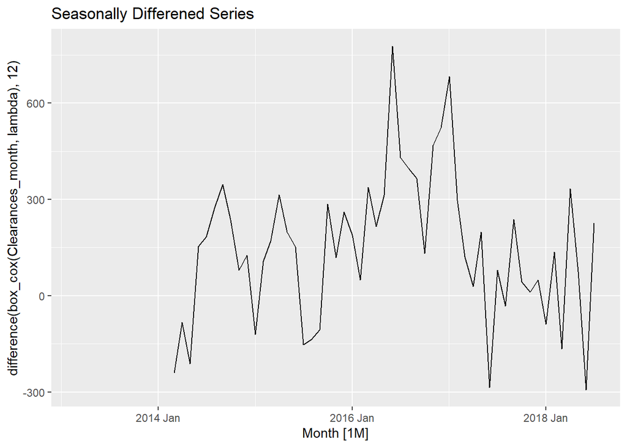

```r
training %>%
autoplot(difference(box_cox(Clearances_month, lambda), 12)) +
labs(title = "Seasonally Differened Series")
```

We can see if a further difference is required:

```r
training %>%
  features(difference(box_cox(Clearances_month, lambda), 12), unitroot_ndiffs)
```

```
## # A tibble: 1 × 1
##   ndiffs
##    <int>
## 1      0
```

This tells us no more differencing necessary- so we are good to go!

We can now see which ARIMA model would be best- we can find 2 models manually, then also use R’s automated function:

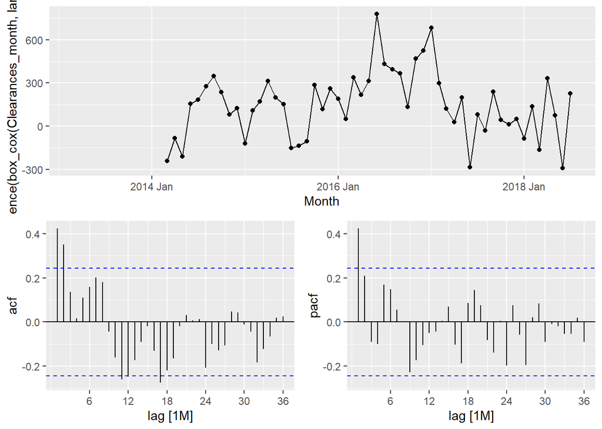

```r
training %>%
gg_tsdisplay(difference(box_cox(Clearances_month, lambda), 12),
plot_type = "partial", lag_max = 36)
```

Above are our two manually suggested models. We now compare these to R’s automated models, to see what model is best:

```r
fit <- training %>%
  model(ARIMA007011 = ARIMA(box_cox(Clearances_month, lambda) ~ pdq(0, 0, 7) + PDQ(0,1,1)),
        ARIMA100110 = ARIMA(box_cox(Clearances_month, lambda) ~ pdq(1, 0, 0) + PDQ(1,1,0)),
        stepwise = ARIMA(box_cox(Clearances_month, lambda)),
        search = ARIMA(box_cox(Clearances_month, lambda), stepwise = FALSE))
fit
```

```
## # A mable: 1 x 4
##    ARIMA007011                        ARIMA100110
##        <model>                            <model>
## 1 <NULL model> <ARIMA(1,0,0)(1,1,0)[12] w/ drift>
## # … with 2 more variables: stepwise <model>, search <model>
## # ℹ Use `colnames()` to see all variable names
```

```r
fit %>% pivot_longer(everything(), names_to = "Model_name",
values_to = "Orders")
```

```
## # A mable: 4 x 2
## # Key:     Model_name [4]
##   Model_name                              Orders
##   <chr>                                  <model>
## 1 ARIMA007011                       <NULL model>
## 2 ARIMA100110 <ARIMA(1,0,0)(1,1,0)[12] w/ drift>
## 3 stepwise    <ARIMA(2,0,0)(0,1,0)[12] w/ drift>
## 4 search      <ARIMA(0,0,2)(0,1,1)[12] w/ drift>
```

Stepwise function recommends <ARIMA(2,0,0)(0,1,0)[12] Search function recommends <ARIMA(0,0,2)(0,1,1)[12] **Note: knit the document to see this!**

We can now see which model is best:

```r
glance(fit)
```

```
## # A tibble: 3 × 8
##   .model      sigma2 log_lik   AIC  AICc   BIC ar_roots   ma_roots
##   <chr>        <dbl>   <dbl> <dbl> <dbl> <dbl> <list>     <list>
## 1 ARIMA100110 42164.   -356.  720.  721.  728. <cpl [13]> <cpl [0]>
## 2 stepwise    41078.   -355.  719.  720.  727. <cpl [2]>  <cpl [0]>
## 3 search      29412.   -353.  716.  717.  726. <cpl [0]>  <cpl [14]>
```

Stepwise and search all have similar AICc values.

```r
forecast <- fit %>%
  forecast(h=12)
accuracy(forecast, pre_moda) %>%
  select(.model, RMSE, MAE, MAPE, MASE)
```

```
## # A tibble: 4 × 5
##   .model       RMSE   MAE   MAPE    MASE
##   <chr>       <dbl> <dbl>  <dbl>   <dbl>
## 1 ARIMA007011 NaN   NaN   NaN    NaN
## 2 ARIMA100110  53.4  45.8   6.98   0.817
## 3 search       51.2  42.2   6.48   0.752
## 4 stepwise     55.6  48.9   7.31   0.873
```

**Go over residual diagnostics**

We now look at residual diagnostics to ensure our models don’t violate any assumptions:

ETS:

```r
ETSmodels %>%
  select(Additive_Dampened) %>%
  report()
```

```
## Series: Clearances_month
## Model: ETS(A,Ad,A)
## Transformation: box_cox(Clearances_month, lambda)
##   Smoothing parameters:
##     alpha = 0.2687205
##     beta  = 0.0001010471
##     gamma = 0.0004181001
##     phi   = 0.9799946
##
##   Initial states:
##      l[0]     b[0]      s[0]     s[-1]     s[-2]     s[-3]     s[-4]     s[-5]
##  1468.799 17.76204 -332.0656 -234.2695 -106.7999 -305.1042 -214.6265 -184.6891
##    s[-6]     s[-7]    s[-8]    s[-9]  s[-10]   s[-11]
##  81.4547 -51.11585 335.9825 459.1278 386.536 165.5695
##
##   sigma^2:  31063.17
##
##      AIC     AICc      BIC
## 959.9736 974.8432 999.1126
```

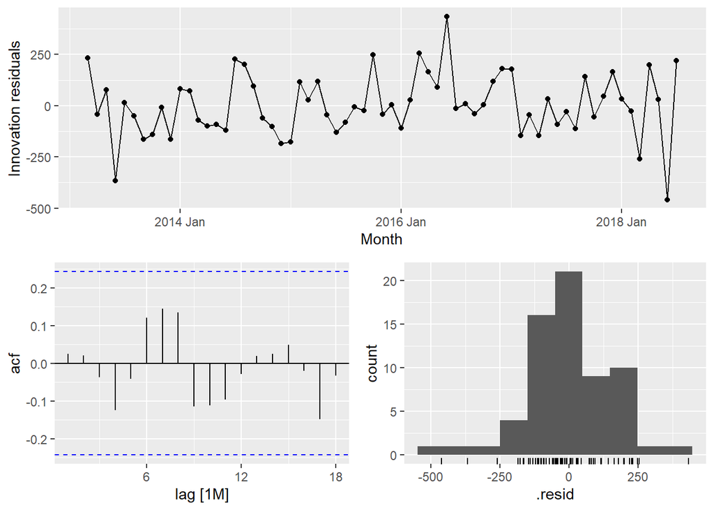

```r
ETS_residuals <- ETSmodels %>%
  select(Additive_Dampened) %>%
  gg_tsresiduals()
ETS_residuals
```

```r
ljung_ETS <- ETSmodels %>%
  select(Additive_Dampened) %>%
  augment() %>%
features(.resid, ljung_box, lag = 24, dof = 16)
ljung_ETS
```

```
## # A tibble: 1 × 3
##   .model            lb_stat lb_pvalue
##   <chr>               <dbl>     <dbl>
## 1 Additive_Dampened    23.2   0.00314
```

p-value less than 0.05, so this model fails the Ljung-box test- we don’t have enough evidence to suggest that the residuals of the ETS model resemble a white-noise series. The model can still be useful for forecasting, but the prediction intervals may not be accurate due to correlated residuals.

ARIMA:

```r
fit %>%
  select(search) %>%
  report()
```

```
## Series: Clearances_month
## Model: ARIMA(0,0,2)(0,1,1)[12] w/ drift
## Transformation: box_cox(Clearances_month, lambda)
##
## Coefficients:
##          ma1     ma2     sma1  constant
##       0.2265  0.2170  -0.8806  161.9525
## s.e.  0.1464  0.1887   1.0928   17.9867
##
## sigma^2 estimated as 29412:  log likelihood=-353.05
## AIC=716.1   AICc=717.38   BIC=725.95
```

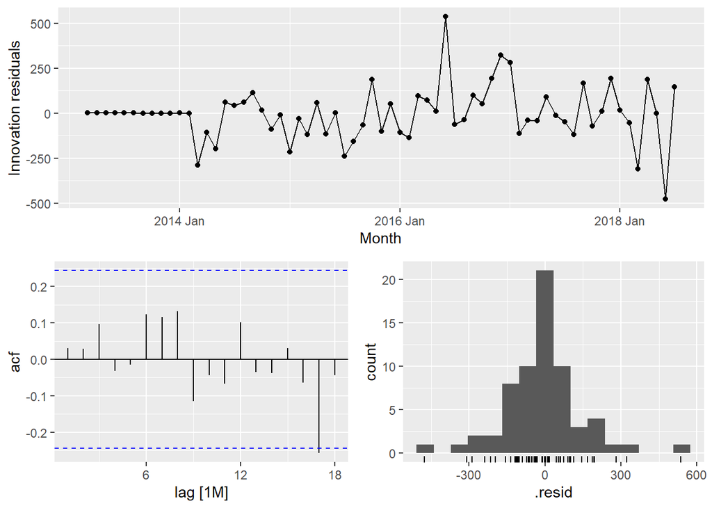

```r
ARIMA_residuals <- fit %>%
  select(search) %>%
  gg_tsresiduals()
ARIMA_residuals
```

```r
ljung_ARIMA <- fit %>%
  select(search) %>%
  augment() %>%
features(.resid, ljung_box, lag = 24, dof = 5)
ljung_ARIMA
```

```
## # A tibble: 1 × 3
##   .model lb_stat lb_pvalue
##   <chr>    <dbl>     <dbl>
## 1 search    21.3     0.322
```

p-value over 0.05, so we have enough evidence to suggest that the residuals of the ARIMA model resemble a white-noise series.

Therefore: our ARIMA model is best!!

Fitted model:

```r
fit %>%
  select(search) %>%
  report()
```

```
## Series: Clearances_month
## Model: ARIMA(0,0,2)(0,1,1)[12] w/ drift
## Transformation: box_cox(Clearances_month, lambda)
##
## Coefficients:
##          ma1     ma2     sma1  constant
##       0.2265  0.2170  -0.8806  161.9525
## s.e.  0.1464  0.1887   1.0928   17.9867
##
## sigma^2 estimated as 29412:  log likelihood=-353.05
## AIC=716.1   AICc=717.38   BIC=725.95
```

We can now produce forecasts for post-MODA changes, and compare to the actual data.

[figure not shown]

```r
best_fc <- pre_moda %>%
  model(ARIMA002011 = ARIMA(box_cox(Clearances_month, lambda) ~ pdq(0, 0, 2) + PDQ(0,1,1))) %>%
  forecast(h = 24)
# best_fc %>%
#   autoplot(data_v3, level = 95) + ggtitle ("Model Comparison")  +
#   ylab ('Prosecutions') +
#   xlab ('Time (Month)')

best_fc %>%
  autoplot(data_v3, level = 90) + ggtitle ("Model Comparison")  +
  ylab ('Prosecutions') +
  xlab ('Time (Month)') + geom_vline(xintercept =  (as.numeric(as.Date(yearmonth("2019 Aug")))- 20),size = 1.6, lty = 1)+
    annotate(x=yearmonth("Aug 2019"),y=+Inf,label="MODA Implemented",vjust=2,geom="label") + bbc_style() +
  theme(legend.position = 'none',
        axis.title = element_text(size = 20),
        plot.subtitle = element_text(size =20)) +
  geom_area(data = data_v2 ,aes(y = Clearances_month, fill = (Month < yearmonth("2019 Aug"))), alpha = .4) +
  labs(subtitle = 'With 95% Projections')
```

```r
ggsave('test3.png')
```

Clear difference- significant change!

## My idea to Monte-Carlo simulate the probability of observing what we saw.

We have a look at the distribution of steps taken each month given the position of the month prior (I.e. the distribution of residuals with respect to the value before).

```r
# data_v3
data_v2
```

```
##         Month Clearances_month
##   1: 2013 Mar              581
##   2: 2013 Apr              588
##   3: 2013 May              637
##   4: 2013 Jun              502
##   5: 2013 Jul              479
##  ---
##  98: 2021 Apr              403
##  99: 2021 May              449
## 100: 2021 Jun              383
## 101: 2021 Jul              367
## 102: 2021 Aug              384
```

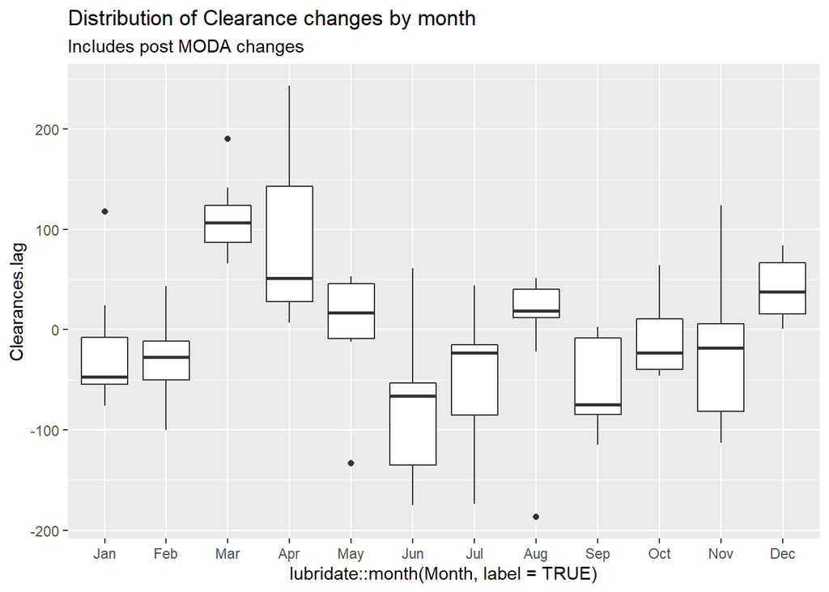

```r
data.premoda = data_v2 %>%
  filter(Month < yearmonth('2019 Aug'))

data_v2 %>%
  mutate(Clearances.lag = Clearances_month - lag(Clearances_month)) %>%
  ggplot(aes(x = lubridate::month(Month, label = TRUE), y = Clearances.lag)) +
  geom_boxplot() +
  labs(title = 'Distribution of Clearance changes by month',
       subtitle = 'Includes post MODA changes')
```

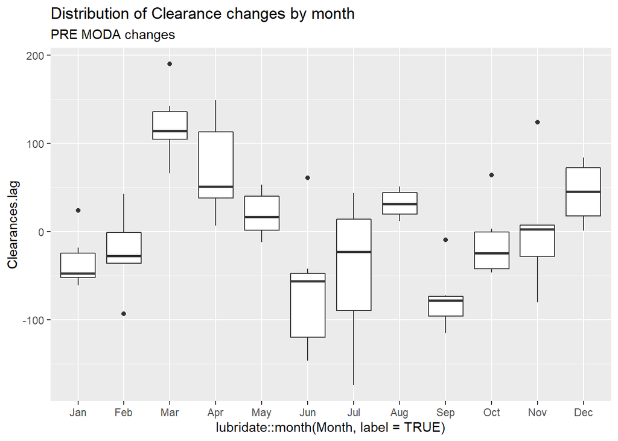

```r
data.premoda %>%
  mutate(Clearances.lag = Clearances_month - lag(Clearances_month)) %>%
  ggplot(aes(x = lubridate::month(Month, label = TRUE), y = Clearances.lag)) +
  geom_boxplot() +
  labs(title = 'Distribution of Clearance changes by month',
       subtitle = 'PRE MODA changes')
```

Given the distribution of each month, we sample one of these values and let it be the “simulated” next value (bootstrap type simulation). We do this a bunch of times and plot the result.

```r
next_steps = data.premoda %>%
  mutate(Clearances.lag = Clearances_month - lag(Clearances_month)) %>%
  group_by(lubridate::month(Month)) %>%
  group_split() %>%
  map(~.x$Clearances.lag)

names(next_steps) = month.name
```

There is one `NA` value obviously, so let’s remove it. I replaced this value with the *66* value which also occurs in March one year, since it is representative somewhat of the data and doesn’t introduce too much bias.

```r
# replace
next_steps$March[1] = 66

next_steps2 = next_steps %>% do.call(rbind, .)
```

```r
# This resulted in a 7/12 rows copying values in order to match the required 7 columns. This is not ideal but will work for now.

# test
next_steps2 = next_steps %>% map(na.omit) %>% do.call(rbind, .)
```

Now to perform a bunch of simulations. Take the data from before

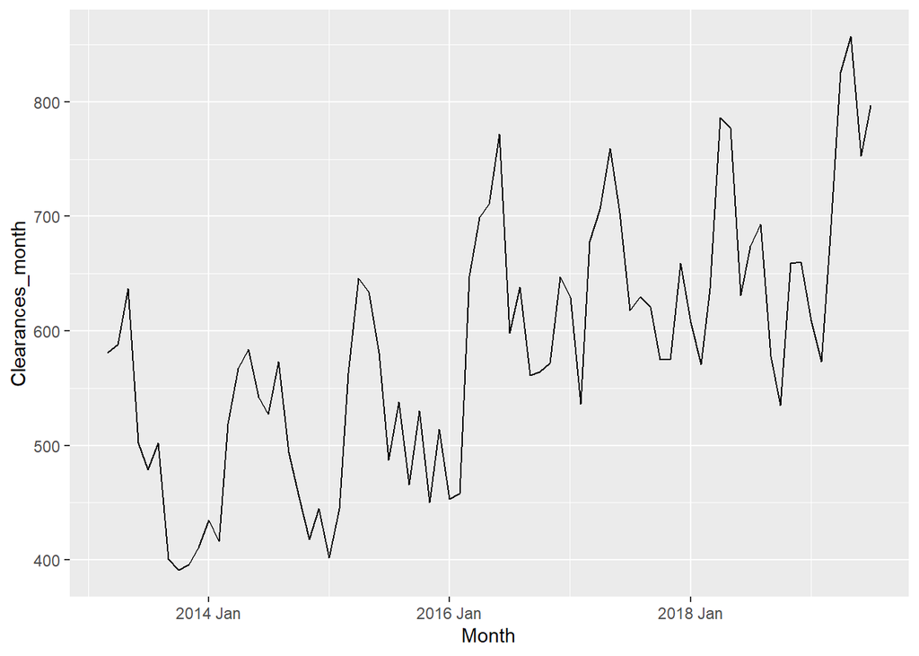

```r
data.premoda %>%
  ggplot(aes(x = Month, y = Clearances_month)) +
  geom_line()
```

And the final point:

```r
data.premoda %>% slice_tail()
```

```
##       Month Clearances_month
## 1: 2019 Jul              797
```

And from July to the end of the dataset, simulate potential clearances.

```r
data_v2 %>% slice_tail()
```

```
##       Month Clearances_month
## 1: 2021 Aug              384
```

```r
n = 100000

# We start our simulation in August 2019 and go to August 2021. Create a matrix of potential observations

next_steps3 = next_steps2[8:12,] %>% rbind(next_steps2) %>% rbind(next_steps2[1:8,])

rownames = c(month.name[8:12], month.name, month.name[1:8])

year = c(rep(2019, 5), rep(2020, 12), rep(2021, 8))

rownames = str_c(year, str_sub(rownames, 1, 3), sep = ' ')

# Number of points to simulate

length(rownames)
```

```
## [1] 25
```

```r
nrow(next_steps3)
```

```
## [1] 25
```

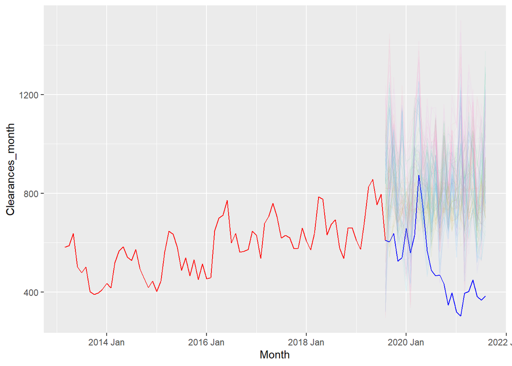

```r
row.names(next_steps3) = rownames

# next_steps3


start = data.premoda %>% slice_tail() %>% pull(Clearances_month)

post_moda_sims = matrix(nrow = n, ncol = nrow(next_steps3))


for (i in 1:n){
  diffs = sample(1:ncol(next_steps3), nrow(next_steps3), replace = TRUE)

  diffs_i = diffs + ncol(next_steps3) * (0:(nrow(next_steps3)-1))
  following_steps = t(next_steps3)[diffs_i]

  post_moda_sims[i,] = start + cumsum(following_steps)
}

# post_moda_sims[1:10,]

# Just for instance:

# Sample Data

# t = number of visualised simulations <= n (plotting only works for less than 1500)
# The higher the t the more it looks like a confidence interval.
t = 100
sample_data = tibble(Month = rep(yearmonth(rownames), t),
                     Clearances_month = c(post_moda_sims[1:t,]),
                     sim = rep(1:t, each = nrow(next_steps3)))



data_v2 %>%
  ggplot(aes(x = Month, y = Clearances_month)) +
  geom_line(col = ifelse(data_v2$Month >= yearmonth('2019 Aug'), 'blue', 'red')) +
  geom_line(data = sample_data, aes(col = as.factor(sim)), alpha = 5/t) +
  theme(legend.position = 'none')
```

Can we use this data to visualise a distribution?

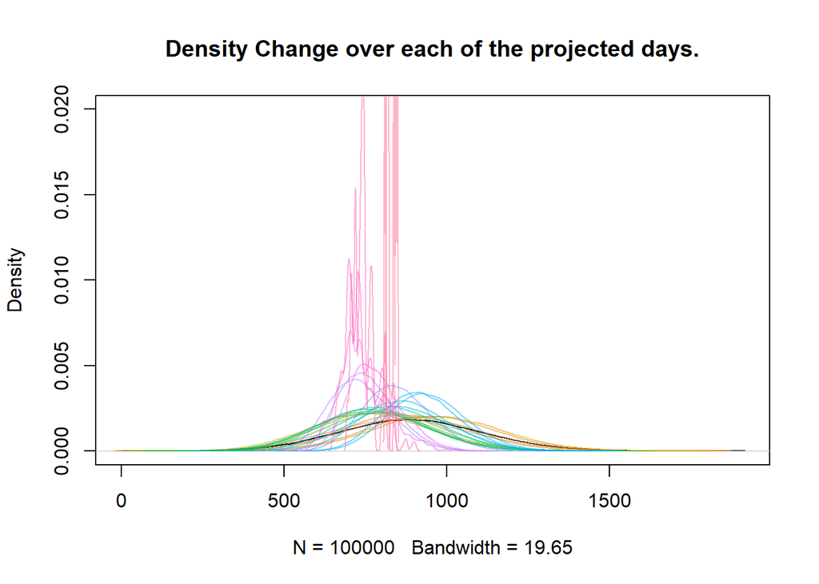

```r
density.data = apply(post_moda_sims, 2, density)
plot(rev(density.data)[[1]], ylim = c(0, 2e-2), main = 'Density Change over each of the projected days.')
map2(rev(density.data)[-1], alpha(scales::hue_pal()(nrow(next_steps3)-1), 0.5), function(x, y) lines(x, col = y))
```

Now to use the Monte Carlo simulated data to estimate the probability of observing what we got. To do this, I will take the cumalitive product of cumalitive probabilities. Make use of the `quantile` function and work under a 2-sided null hypothesis.  
Not sensible for non-parametric bootstrap.

```r
actual_data = data_v2 %>% filter(Month >= yearmonth('2019 Aug'))

percentiles = numeric(nrow(actual_data))

for (i in 1:length(actual_data$Clearances_month)){
  booted_data = post_moda_sims[,i]
  dist_boot = ecdf(booted_data)

  observed = actual_data$Clearances_month[i]

  percentiles[i] = dist_boot(observed)
}

# Want to normalise these percentiles so if they're greater than 0.5, then they are calculated from the right side. Crude and I am sure there is a better way to do this.

percentiles[percentiles > 0.5] = 1 - percentiles[percentiles > 0.5]
percentiles = percentiles * 2

percentiles
```

```
##  [1] 0.00000 0.00000 0.00000 0.00000 0.00000 0.26394 0.05150 0.02468 0.72950
## [10] 0.08182 0.01370 0.02086 0.00708 0.04160 0.03106 0.00838 0.01194 0.00532
## [19] 0.00752 0.00622 0.00262 0.00484 0.00772 0.02090 0.01750
```

```r
summary(percentiles)
```

```
##    Min. 1st Qu.  Median    Mean 3rd Qu.    Max.
## 0.00000 0.00484 0.00838 0.05435 0.02468 0.72950
```

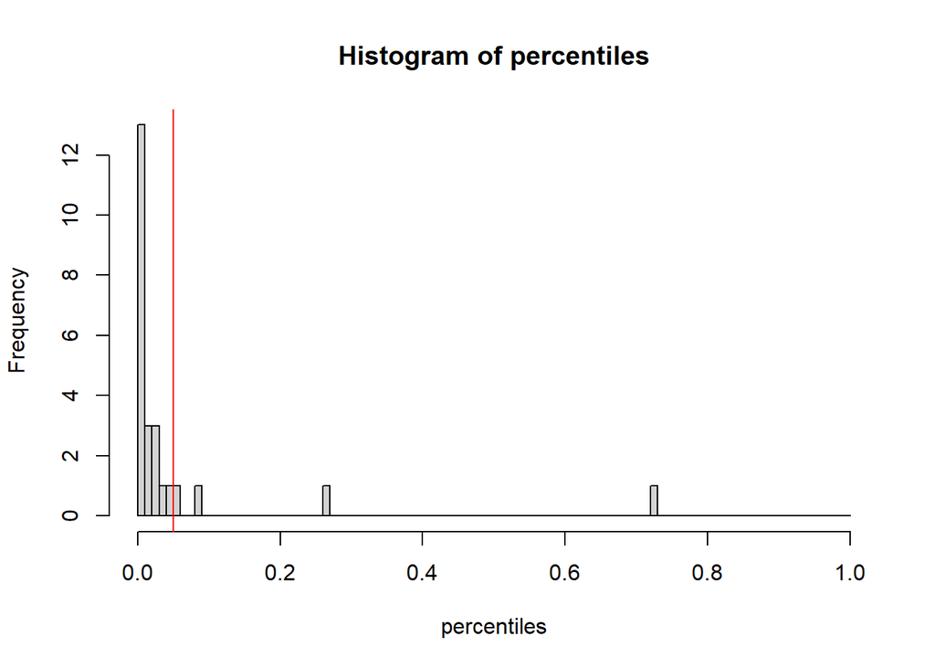

```r
hist(percentiles, breaks = seq(0, 1, 0.01))
abline(v = 0.05, col = 'red')
```

Maybe a parametric bootstrap is more sensible?  
To do this, we’ll get means and standard deviations of each step and assume normality.

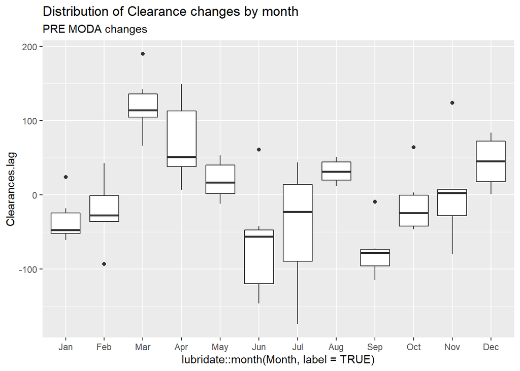

```r
data.premoda %>%
  mutate(Clearances.lag = Clearances_month - lag(Clearances_month)) %>%
  ggplot(aes(x = lubridate::month(Month, label = TRUE), y = Clearances.lag)) +
  geom_boxplot() +
  labs(title = 'Distribution of Clearance changes by month',
       subtitle = 'PRE MODA changes')
```

```r
(month_dists = data.premoda %>%
  mutate(Clearances.lag = Clearances_month - lag(Clearances_month)) %>%
  group_by(Month = lubridate::month(Month, label = TRUE, abbr = FALSE)) %>%
  summarise(mean = mean(Clearances.lag, na.rm = TRUE), sd = sd(Clearances.lag, na.rm = TRUE)))
```

```
## # A tibble: 12 × 3
##    Month       mean    sd
##    <ord>      <dbl> <dbl>
##  1 January   -33.5   31.8
##  2 February  -22.7   45.6
##  3 March     122.    41.7
##  4 April      72.7   55.2
##  5 May        20.1   25.8
##  6 June      -67.9   70.2
##  7 July      -43.4   79.2
##  8 August     31.8   15.9
##  9 September -75.5   36.5
## 10 October   -11.8   42.1
## 11 November    3.33  68.1
## 12 December   44.3   34.5
```

```r
means = month_dists$mean
sds = month_dists$sd
```

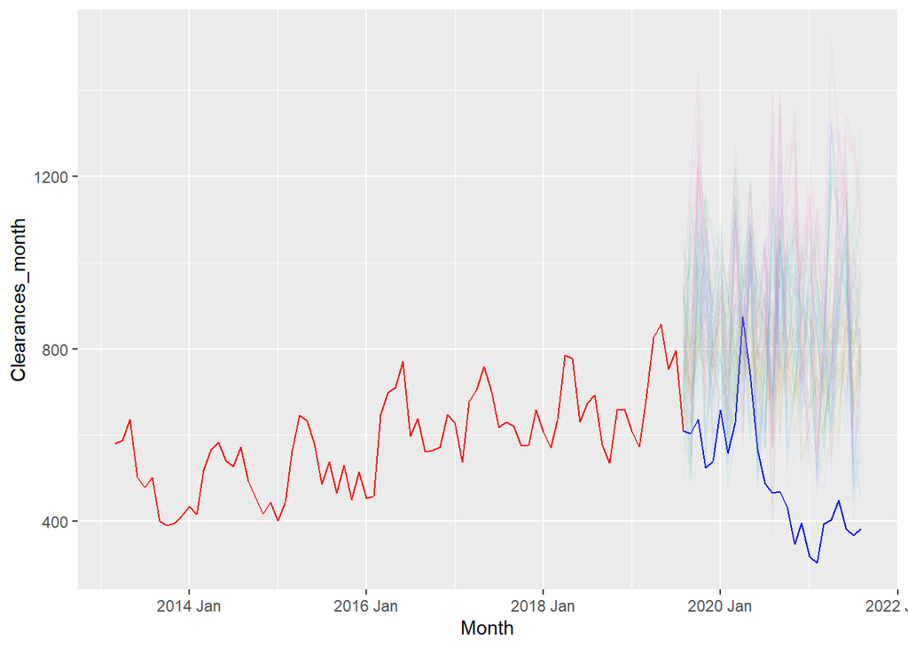

```r
n = 100000

# We start our simulation in August 2019 and go to August 2021. Create a matrix of potential observations

means_recy = c(means[8:12], means, means[1:8])
sds_recy = c(sds[8:12], sds, sds[1:8])

# Figure out the residuals
post_moda_sims_para = rnorm(n * length(means_recy), means_recy, sds_recy)

# Convert to a matrix
post_moda_sims_para = t(matrix(post_moda_sims_para, nrow = length(means_recy)))

# Calculate the cumulative sum and add the start.

for (i in 1:n) post_moda_sims_para[i,] = cumsum(post_moda_sims_para[i,]) + start




# Just for instance:

# Sample Data

# t = number of visualised simulations <= n (plotting only works for less than 1500)
# The higher the t the more it looks like a confidence interval.
t = 100
sample_data = tibble(Month = rep(yearmonth(rownames), t),
                     Clearances_month = c(post_moda_sims_para[1:t,]),
                     sim = rep(1:t, each = ncol(post_moda_sims_para)))



data_v2 %>%
  ggplot(aes(x = Month, y = Clearances_month)) +
  geom_line(col = ifelse(data_v2$Month >= yearmonth('2019 Aug'), 'blue', 'red')) +
  geom_line(data = sample_data, aes(col = as.factor(sim)), alpha = 5/t) +
  theme(legend.position = 'none')
```

Can we use this data to visualise a distribution?

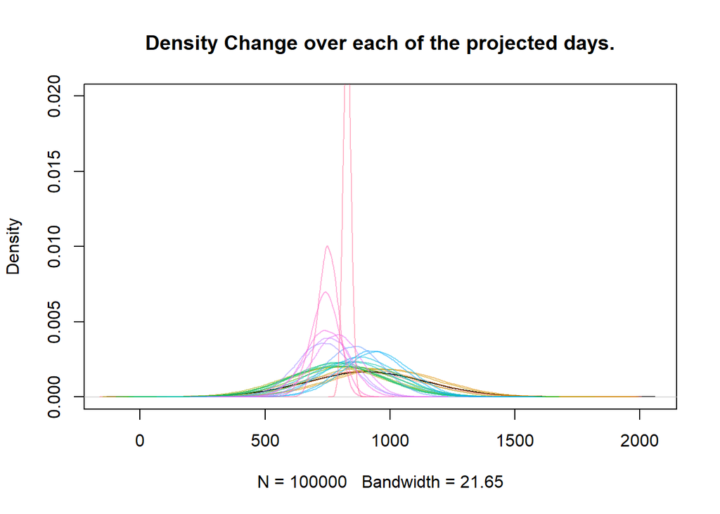

```r
density.data = apply(post_moda_sims_para, 2, density)
plot(rev(density.data)[[1]], ylim = c(0, 2e-2), main = 'Density Change over each of the projected days.')
map2(rev(density.data)[-1], alpha(scales::hue_pal()(length(density.data)-1), 0.5), function(x, y) lines(x, col = y))
```

```r
actual_data = data_v2 %>% filter(Month >= yearmonth('2019 Aug'))

percentiles = numeric(nrow(actual_data))

for (i in 1:length(actual_data$Clearances_month)){
  booted_data = post_moda_sims_para[,i]
  dist_boot = ecdf(booted_data)

  observed = actual_data$Clearances_month[i]

  percentiles[i] = dist_boot(observed)
}

# Want to normalise these percentiles so if they're greater than 0.5, then they are calculated from the right side. Crude and I am sure there is a better way to do this.

percentiles[percentiles > 0.5] = 1 - percentiles[percentiles > 0.5]
percentiles = percentiles * 2

percentiles
```

```
##  [1] 0.00000 0.00016 0.07166 0.01340 0.00910 0.33580 0.11394 0.06012 0.68214
## [10] 0.12222 0.03864 0.04130 0.01814 0.06562 0.05258 0.02276 0.02668 0.01588
## [19] 0.02038 0.01558 0.00860 0.01246 0.01790 0.03460 0.02998
```

```r
summary(percentiles)
```

```
##    Min. 1st Qu.  Median    Mean 3rd Qu.    Max.
## 0.00000 0.01558 0.02668 0.07319 0.06012 0.68214
```

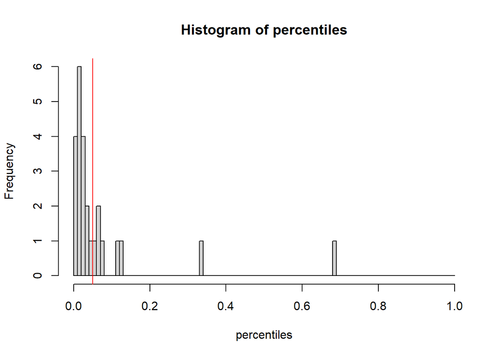

```r
hist(percentiles, breaks = seq(0, 1, 0.01))
abline(v = 0.05, col = 'red')
```

We can use the `pnorm` function to figure out the actual probability of observing something like this given the monte-carlo assumption.

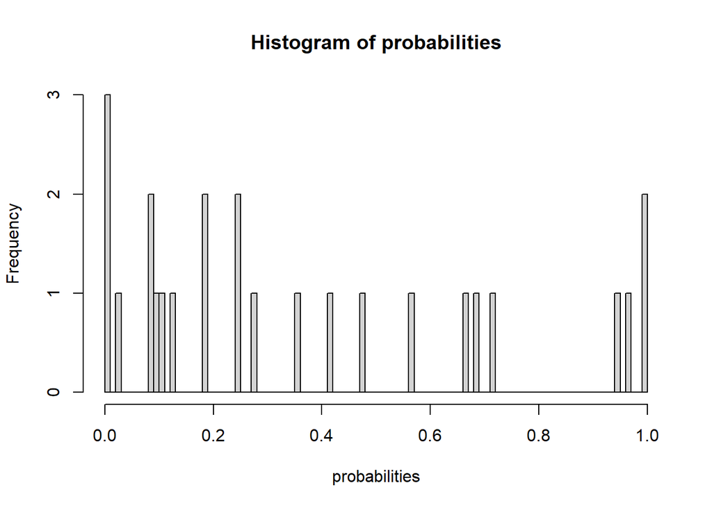

```r
# goes in order of Aug 2019 - Aug 2021
actual_lags = actual_data$Clearances_month - lag(actual_data$Clearances_month)

# calculate first lag.
actual_lags[1] = data_v2[data_v2$Month == yearmonth('2019 August') | data_v2$Month == (yearmonth('2019 August')-1)] %>% pull(Clearances_month) %>% (function(x) {x[2]-x[1]})

# Calculate cumulative probabilities
probabilities = pnorm(actual_lags, means_recy, sds_recy)

# Convert upper probabilities to lowers and double.

probabilities[probabilities > 0.5] = probabilities[probabilities > 0.5] - 0.5

# Double
probabilities = probabilities * 2

hist(probabilities, breaks = seq(0, 1, 0.01))
```

```r
# Actual probability is the cumulative product of it all?

prod(probabilities)
```

```
## [1] 2.094656e-66
```

That’s statistical significance.

Plot the confidence interval over time. Notice that the simulated variance is increasing with time.

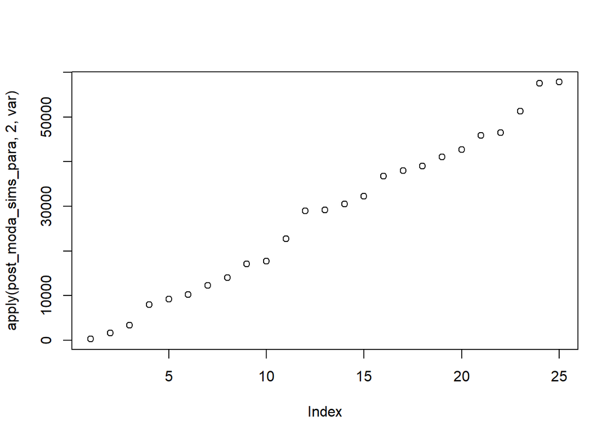

```r
plot(apply(post_moda_sims_para, 2, var))
```

```r
simulated_mean = apply(post_moda_sims_para, 2, mean)
simulated_confint = rep(simulated_mean, each = 2) + c(1, -1) * 2 * rep(apply(post_moda_sims_para, 2, sd), each = 2)
simulated_confint = simulated_confint %>% matrix(nrow = 2) %>% t()

dates = data_v2[data_v2$Month >= yearmonth('2019 Aug'),]$Month

projection_data = cbind(simulated_mean, simulated_confint, dates) %>% as_tibble() %>% rename('upper' = V2, 'lower' = V3) %>% mutate(dates = as.Date(dates, origin='1970-01-01'))
```

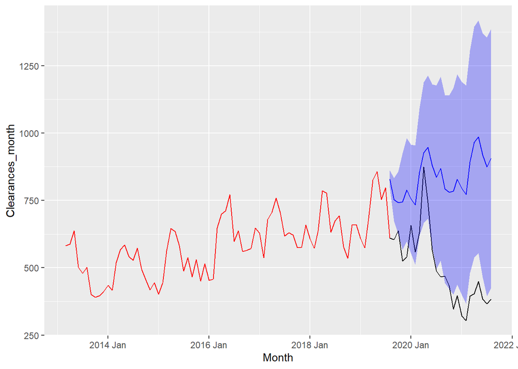

```r
data_v2 %>%
  ggplot(aes(x = Month, y = Clearances_month)) +
  geom_line(col = ifelse(data_v2$Month >= yearmonth('2019 Aug'), 'black', 'red')) +
  geom_line(data = projection_data, aes(x = dates, y = simulated_mean), col = 'blue') +
  geom_ribbon(data = projection_data, aes(x = dates, y = simulated_mean, ymin = lower, ymax = upper), alpha = 0.3, fill = 'blue')
```

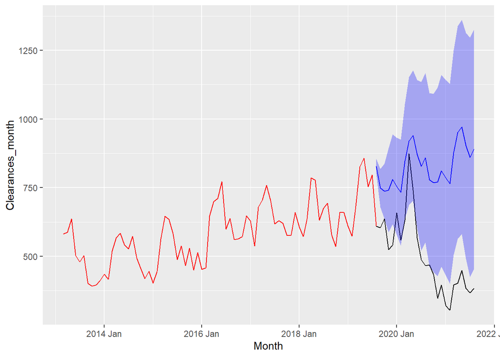

```r
simulated_mean = apply(post_moda_sims, 2, mean)
simulated_confint = rep(simulated_mean, each = 2) + c(1, -1) * 2 * rep(apply(post_moda_sims, 2, sd), each = 2)
simulated_confint = simulated_confint %>% matrix(nrow = 2) %>% t()

dates = data_v2[data_v2$Month >= yearmonth('2019 Aug'),]$Month

projection_data = cbind(simulated_mean, simulated_confint, dates) %>% as_tibble() %>% rename('upper' = V2, 'lower' = V3) %>% mutate(dates = as.Date(dates, origin='1970-01-01'))

data_v2 %>%
  ggplot(aes(x = Month, y = Clearances_month)) +
  geom_line(col = ifelse(data_v2$Month >= yearmonth('2019 Aug'), 'black', 'red')) +
  geom_line(data = projection_data, aes(x = dates, y = simulated_mean), col = 'blue') +
  geom_ribbon(data = projection_data, aes(x = dates, y = simulated_mean, ymin = lower, ymax = upper), alpha = 0.3, fill = 'blue')
```

## I got it

To estimate the probability of a real effect of the legislation change, we can use this simulated data that we have created as “a set of potential outcomes given nothing has changed”.  
We then estimate some statistic to show lack of fit such as RSS. We calculate the RSS of the actual data given our model, and use the simulated data to also calculate their RSS.  
We then figure out the proportion of the simulated RSS values are *greater* than the actual RSS given the fitted model, and that is out p-value. (greater since a worse fit is less likely under the assumption of no change).

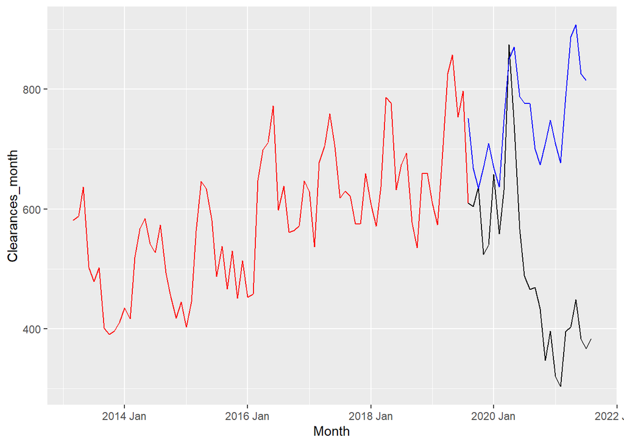

```r
fc_data = best_fc %>% as_tibble() %>% select(Month, .mean)

data_v2 %>%
  ggplot(aes(x = Month, y = Clearances_month)) +
  geom_line(col = ifelse(data_v2$Month >= yearmonth('2019 Aug'), 'black', 'red')) +
  geom_line(data = fc_data, aes(x = Month, y = .mean), col = 'blue')
```

Can we please figure out how to get random number from the distribution objects given in the model?

```r
best_fc$Clearances_month
```

```
## <distribution[24]>
##  [1] t(N(2578, 36133)) t(N(2233, 38374)) t(N(2098, 38892)) t(N(2240, 38892))
##  [5] t(N(2403, 38892)) t(N(2239, 38891)) t(N(2109, 38887)) t(N(2568, 38826))
##  [9] t(N(2996, 38826)) t(N(3081, 38826)) t(N(2729, 38826)) t(N(2682, 38826))
## [13] t(N(2681, 43506)) t(N(2365, 43796)) t(N(2259, 43864)) t(N(2400, 43864))
## [17] t(N(2564, 43864)) t(N(2400, 43863)) t(N(2270, 43859)) t(N(2729, 43797))
## [21] t(N(3156, 43797)) t(N(3241, 43797)) t(N(2890, 43797)) t(N(2843, 43797))
```

We’ll use my model now just for reference.

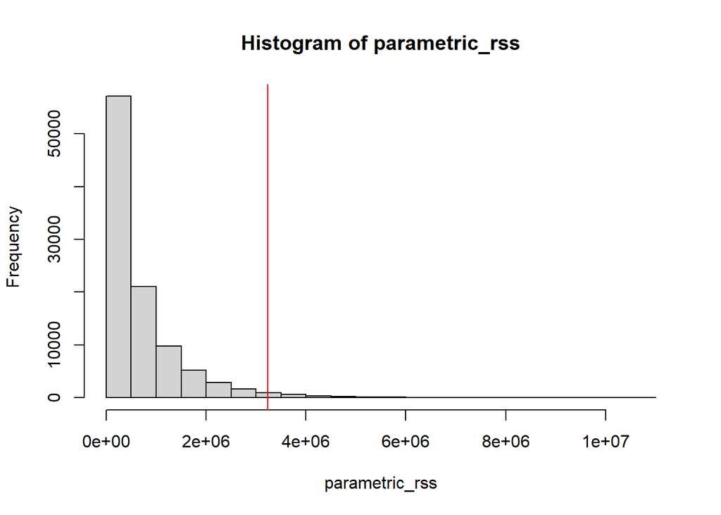

```r
parametric_rss = apply(sweep(post_moda_sims_para, 2, projection_data$simulated_mean)^2, 1, sum)
nonpara_rss = apply(sweep(post_moda_sims, 2, projection_data$simulated_mean)^2, 1, sum)

actual_rss = sum((projection_data$simulated_mean - actual_data$Clearances_month)^2)

hist(parametric_rss)
abline(v = actual_rss, col = 'red')
```

```r
# P-value
(p_val = sum(parametric_rss > actual_rss) / length(nonpara_rss))
```

```
## [1] 0.0186
```

That is just 1.9% significance.

## Now with the actually good model

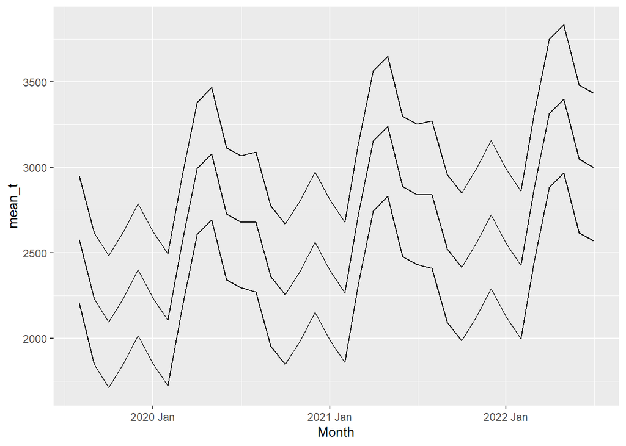

```r
ts.model = pre_moda %>%
  model(ARIMA002011 = ARIMA(box_cox(Clearances_month, lambda) ~ pdq(0, 0, 2) + PDQ(0,1,1)))

# ts.model %>% glance()

huh = ts.model %>% forecast(h=36) %>% hilo(level = 95) %>% unpack_hilo('95%')

huh %>%
  mutate(mean_t = box_cox(.mean, lambda),
         lower_t = box_cox(`95%_lower`, lambda),
         upper_t = box_cox(`95%_upper`, lambda)) %>%
  ggplot(aes(x = Month, y = mean_t)) +
  geom_line() +
  geom_line(aes(y = lower_t)) +
  geom_line(aes(y = upper_t))
```

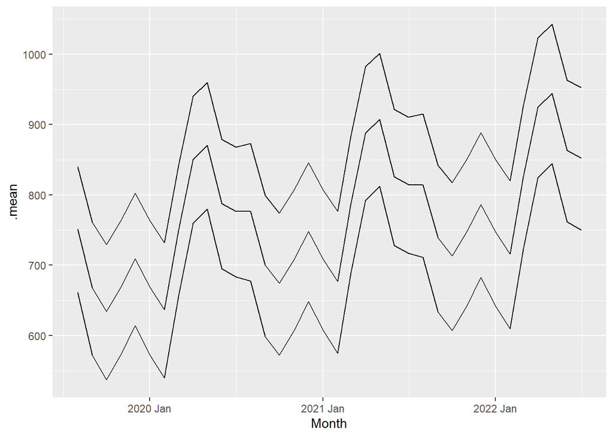

```r
huh %>%
  ggplot(aes(x = Month, y = .mean)) +
  geom_line() +
  geom_line(aes(y = `95%_lower`)) +
  geom_line(aes(y = `95%_upper`))
```

Disribution looks roughly normal. Lets keep to the definition and apply the transformation.

$$\mu + 1.96 \times \sigma =
upper$$

$$\implies \sigma = \frac{upper -
\mu}{1.96}$$

Likewise for lower. Ideally they should be about the same, although on observation of the graph above, it doesn’t look like it. A safe bet would be to take the average standard deviation between the two.

```r
# 1.96 is an approximation for the 97.5% percentile. Call the true value t
(t = qnorm(0.975))
```

```
## [1] 1.959964
```

```r
huh_t = huh %>%
  mutate(mean_t = box_cox(.mean, lambda),
         lower_t = box_cox(`95%_lower`, lambda),
         upper_t = box_cox(`95%_upper`, lambda))

# Mean sd
sds = ((huh_t$upper_t - huh_t$mean_t) / t + (huh_t$lower_t - huh_t$mean_t) / -t) / 2
sds
```

```
##  [1] 190.0877 195.8921 197.2099 197.2099 197.2099 197.2077 197.1980 197.0423
##  [9] 197.0423 197.0423 197.0423 197.0423 208.5815 209.2760 209.4362 209.4362
## [17] 209.4362 209.4341 209.4250 209.2784 209.2784 209.2784 209.2784 209.2784
## [25] 220.1772 220.8353 220.9871 220.9871 220.9871 220.9852 220.9765 220.8375
## [33] 220.8375 220.8375 220.8375 220.8375
```

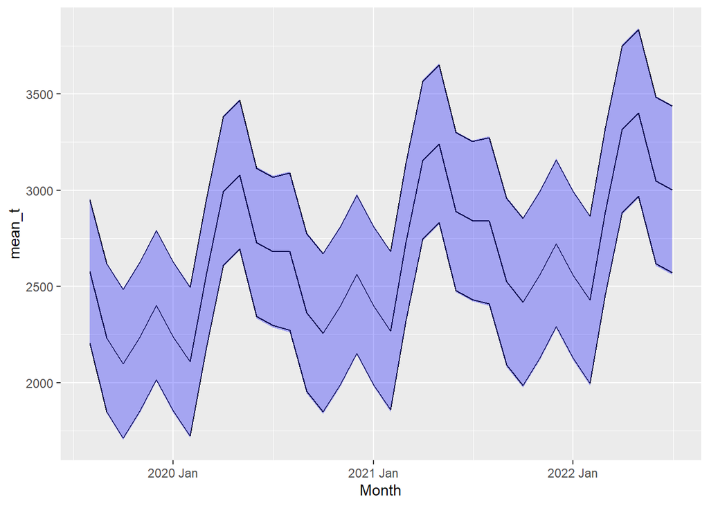

```r
huh_t %>% as_tibble() %>%
  cbind(sds) %>% as_tibble() %>%
  ggplot(aes(x = Month, y = mean_t)) +
  geom_line() +
  geom_line(aes(y = lower_t)) +
  geom_line(aes(y = upper_t)) +
  geom_ribbon(aes(ymin = mean_t - sds * 2, ymax = mean_t + sds * 2), alpha = 0.3, fill = 'blue')
```

Looks like a perfect fit! Now we can use it to simulate some data!

```r
huh_t = huh_t %>% as_tibble() %>%
  cbind(sds) %>% as_tibble() %>%
  filter(Month < yearmonth('2021 Sep'))


sim_data = huh_t %>% select(Month, mean_t, sds)

sim_matrix = as.matrix(sim_data[,2:3])
row.names(sim_matrix) = (sim_data$Month %>% as.character())

sim_matrix
```

```
##            mean_t      sds
## 2019 Aug 2576.551 190.0877
## 2019 Sep 2231.277 195.8921
## 2019 Oct 2096.531 197.2099
## 2019 Nov 2238.235 197.2099
## 2019 Dec 2401.849 197.2099
## 2020 Jan 2237.744 197.2077
## 2020 Feb 2107.441 197.1980
## 2020 Mar 2566.793 197.0423
## 2020 Apr 2994.536 197.0423
## 2020 May 3079.511 197.0423
## 2020 Jun 2727.810 197.0423
## 2020 Jul 2681.160 197.0423
## 2020 Aug 2679.760 208.5815
## 2020 Sep 2363.132 209.2760
## 2020 Oct 2257.013 209.4362
## 2020 Nov 2398.714 209.4362
## 2020 Dec 2562.327 209.4362
## 2021 Jan 2398.223 209.4341
## 2021 Feb 2267.922 209.4250
## 2021 Mar 2727.270 209.2784
## 2021 Apr 3155.014 209.2784
## 2021 May 3239.991 209.2784
## 2021 Jun 2888.288 209.2784
## 2021 Jul 2841.637 209.2784
## 2021 Aug 2840.246 220.1772
```

```r
n = 100000

# Generate the data :D
parametric_ts_sims = rnorm(n * nrow(sim_matrix), sim_matrix[,1], sim_matrix[,2])
parametric_ts_sims[1:10]
```

```
##  [1] 2615.584 2101.602 2047.683 2061.105 2596.890 2542.511 2084.864 2375.209
##  [9] 2936.771 3120.819
```

```r
# Transform the data with inverse box cox NO DONT DO THAT! BAD! DO IT LATER!
# parametric_ts_sims_t = inv_box_cox(parametric_ts_sims, lambda)
# parametric_ts_sims_t[1:10]

# Convert to matrix
parametric_ts_sims_matrix = t(matrix(parametric_ts_sims, nrow = nrow(sim_matrix)))
dim(parametric_ts_sims_matrix)
```

```
## [1] 100000     25
```

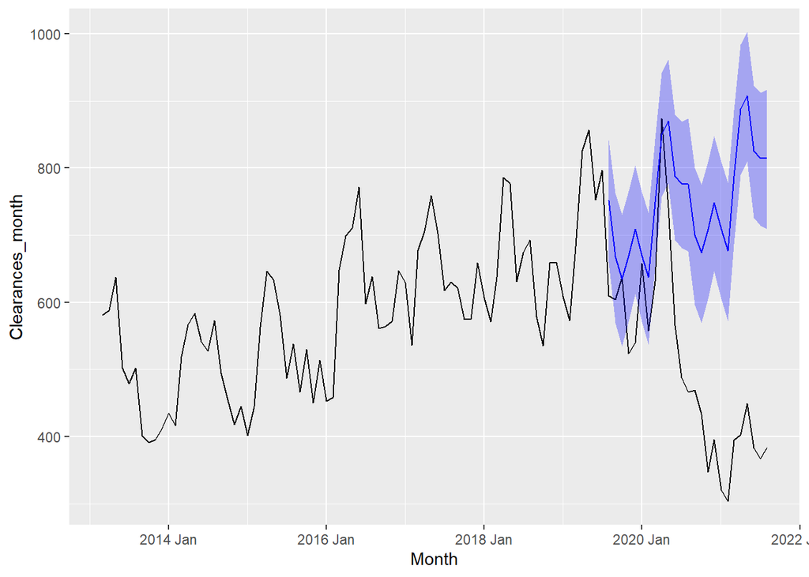

```r
# Visualise
simulated_confint = inv_box_cox(rep(sim_matrix[,1], each = 2) + c(1, -1) * 2 * rep(apply(parametric_ts_sims_matrix, 2, sd), each = 2), lambda)
simulated_confint = simulated_confint %>% matrix(nrow = 2) %>% t()


proj_data = sim_data %>%
  cbind(simulated_confint) %>%
  as_tibble() %>% rename('lower' = `1`, 'upper' = `2`) %>%
  mutate(mean = inv_box_cox(mean_t, lambda))


data_v2 %>%
  ggplot(aes(x = Month, y = Clearances_month)) +
  geom_line() +
  geom_line(data = proj_data, aes(y = mean), col = 'blue') +
  geom_ribbon(data = proj_data, aes(y = mean, ymin = lower, ymax = upper), fill = 'blue', alpha = 0.3)
```

Now to actually calculate the p_value

```r
predicted_post_moda = huh_t$.mean
actual_post_moda = data_v2 %>% filter(Month >= yearmonth('2019 Aug')) %>%
  pull(Clearances_month)

# rss of the actual data against model
(rss_actual = sum((predicted_post_moda - actual_post_moda)^2))
```

```
## [1] 2178652
```

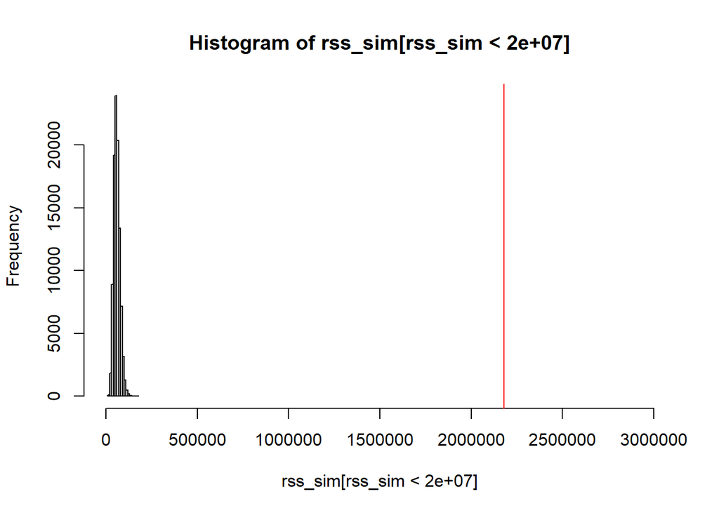

```r
# get the rss of the simulated data
rss_sim = apply((sweep(inv_box_cox(parametric_ts_sims_matrix, lambda), 2, predicted_post_moda))^2, 1, sum)

# plot (filter first)

hist(rss_sim[rss_sim < 2e7], xlim = c(0, 3e6))
abline(v = rss_actual, col = 'red')
```

```r
# p
sum(rss_sim > rss_actual) / length(rss_sim)
```

```
## [1] 0
```

Clear difference! Very unlikely.